# Deep Learning for Computer Vision # week1

**Instructor: Dr. Phuriwat Worrawichaipat, Silpakorn University**

Topic: Basic Plotting and Image display with matplotlib

ในโน้ตบุ๊กนี้ เราจะเรียนรู้เกี่ยวกับเทคนิคการแสดงผลข้อมูลที่สำคัญสองรูปแบบ ซึ่งมักถูกใช้งานในงาน Deep Learning และ Computer Vision

1. **การพล็อตกราฟเส้น (Line Plotting)** – ใช้สำหรับติดตามค่าเช่น loss หรือ accuracy ระหว่างการฝึกโมเดล AI
2. **การแสดงภาพ (Image Display)** – ใช้ในการดูข้อมูลภาพที่ป้อนเข้าโมเดล, ผลลัพธ์ที่โมเดลสร้างขึ้น, หรือการเปลี่ยนแปลงต่าง ๆ ที่เกิดขึ้นกับภาพ

## Part 1: Line Plotting

- `import matplotlib.pyplot as plt`  
  เป็นการนำเข้าโมดูล `pyplot` จากไลบรารี `matplotlib` ซึ่งใช้ในการสร้างกราฟและการแสดงผลข้อมูลเชิงภาพ เช่น
  - กราฟเส้น (`plt.plot()`)
  - กราฟแท่ง (`plt.bar()`)
  - การแสดงภาพ (`plt.imshow()`)  
    เราตั้งชื่อย่อเป็น `plt` เพื่อให้ง่ายต่อการใช้งาน
- `import math`  
  เป็นไลบรารีคณิตศาสตร์พื้นฐานที่มาพร้อมกับ Python เช่น `math.sqrt(x)` และ `math.sin(x)`

```python
import matplotlib.pyplot as plt
import math
import numpy as np
```

`np.arange(start, stop, step)`  
คือฟังก์ชันของ NumPy ที่ใช้สร้างอาเรย์ของตัวเลขที่เรียงต่อกัน โดยเริ่มจาก `start` ไปจนถึงค่าก่อน `stop` (ไม่รวม `stop`) และเพิ่มทีละ `step`

- start = 0.0 → จุดเริ่มต้นของอาเรย์
- stop = 2 * math.pi → ค่าจบ (ประมาณ 6.28) ซึ่งเท่ากับ 1 รอบของวงกลมในหน่วยเรเดียน (360 องศา)
- step = 0.1 → ค่าที่เพิ่มในแต่ละขั้น

```python
x = np.arange(0.0, 2*math.pi, 0.1)
print(x)
```

```
[0.  0.1 0.2 0.3 0.4 0.5 0.6 0.7 0.8 0.9 1.  1.1 1.2 1.3 1.4 1.5 1.6 1.7
 1.8 1.9 2.  2.1 2.2 2.3 2.4 2.5 2.6 2.7 2.8 2.9 3.  3.1 3.2 3.3 3.4 3.5
 3.6 3.7 3.8 3.9 4.  4.1 4.2 4.3 4.4 4.5 4.6 4.7 4.8 4.9 5.  5.1 5.2 5.3
 5.4 5.5 5.6 5.7 5.8 5.9 6.  6.1 6.2]
```

```python
y = [math.sin(val) for val in x]
print(y)
print("\n^^ ค่า sin หลายๆค่าของวงกลม 1 วง")
```

```
[0.0, 0.09983341664682815, 0.19866933079506122, 0.2955202066613396, 0.3894183423086505, 0.479425538604203, 0.5646424733950355, 0.6442176872376911, 0.7173560908995228, 0.7833269096274834, 0.8414709848078965, 0.8912073600614354, 0.9320390859672264, 0.963558185417193, 0.9854497299884603, 0.997494986604…

^^ ค่า sin หลายๆค่าของวงกลม 1 วง
```

### Default Line Plot

ลักษณะนี้ทาง matplotlib จะเชื่อมต่อจุดคู่ลำดับ `(x0, y0)`, `(x1, y1)` ... ต่อกันไปเรื่อย ๆ ทำให้ได้เส้นที่ต่อเนื่องกันไปเป็นเนื้อเดียวกัน

```python
print("x => ", [round(val, 2) for val in x[:20]])
print("y => ", [round(val, 2) for val in y[:20]])
```

```
x =>  [np.float64(0.0), np.float64(0.1), np.float64(0.2), np.float64(0.3), np.float64(0.4), np.float64(0.5), np.float64(0.6), np.float64(0.7), np.float64(0.8), np.float64(0.9), np.float64(1.0), np.float64(1.1), np.float64(1.2), np.float64(1.3), np.float64(1.4), np.float64(1.5), np.float64(1.6), np.f…
y =>  [0.0, 0.1, 0.2, 0.3, 0.39, 0.48, 0.56, 0.64, 0.72, 0.78, 0.84, 0.89, 0.93, 0.96, 0.99, 1.0, 1.0, 0.99, 0.97, 0.95]
```

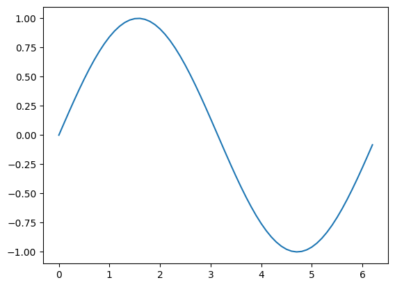

```python
plt.plot(x, y)
```

### Marker Plot

ในบางครั้ง เราอยากจะแสดงเฉพาะตำแหน่งจุด ไม่ต้องการเส้น เราก็สามารถทำได้ด้วยการระบุรูปร่างและสีของจุดที่ต้องการวาด ในที่นี้เราเลือกสีแดง (red) โดยใช้ Marker เครื่องหมาย + แทนตำแหน่งจุด

> ใส่ `'r+'` โดย r คือสีแดง และ + คือ marker

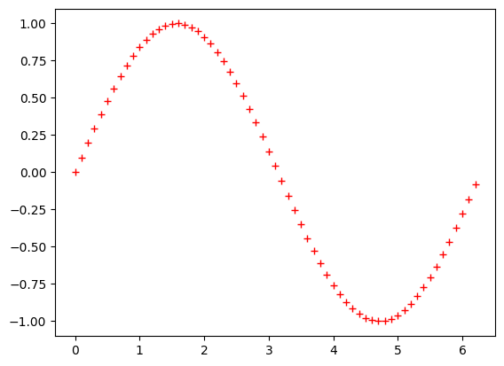

```python
plt.plot(x, y, 'r+')
```

### ลองเปลี่ยนสีและลักษณะของจุด

คราวนี้เราลองเลือกสีน้ำเงิน (blue) และใช้จุดกลุมเป็นเครื่องหมายตำแหน่งจุด มาถึงจุดนี้แล้ว เราคงจะสงสัยว่าแล้วจะรู้ได้ไงว่ามีสีอะไรและมาร์คเกอร์แบบไหนที่ใช้ได้บ้าง

> ถ้าใครสงสัยก็ลองดูโนัตเกี่ยวกับสีและมาร์คเกอร์ได้ที่[ลิงค์นี้](https://matplotlib.org/api/_as_gen/matplotlib.pyplot.plot.html)  
> ถ้าใครสงสัยว่า markdown ใน Jupyter Notebook ที่น่าสนใจมีอะไรบ้างก็ลองดูที่[ลิงค์นี้](https://medium.com/ibm-data-science-experience/markdown-for-jupyter-notebooks-cheatsheet-386c05aeebed)

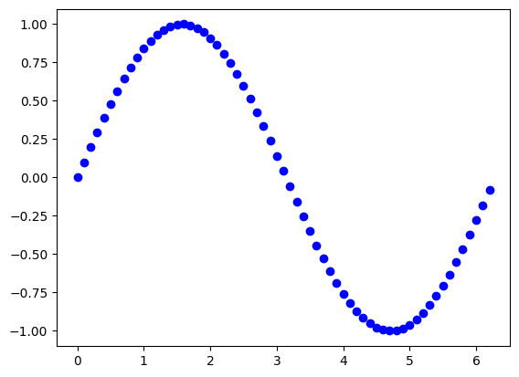

```python
plt.plot(x, y, 'bo')
```

**ลองพล็อตจุดแบบห่าง ๆ กัน ซึ่งทำได้โดยการเพิ่ม step size ใน `arange()` จาก 0.1 ให้เป็น 0.2**

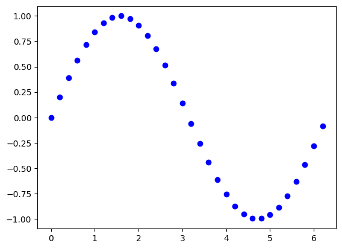

```python
x = np.arange(0.0, 2*math.pi, 0.2)
y = [math.sin(val) for val in x]
plt.plot(x, y, 'bo')
```

### แล้วถ้าอยากพล็อตทั้งเส้นทั้งจุดล่ะ

เท่าที่เห็น พอเรามีการระบุลักษณะของมาร์คเกอร์ลงในคำสั่ง plot ปุ๊บ เส้นก็หายปั๊บ แต่ถ้าเราอยากจะพล็อตทั้งเส้นและจุดล่ะ จะทำยังไง ในกรณีเช่นนี้ วิธีที่นิยมที่สุดก็คือการระบุชนิดของเส้นเข้าไปด้วย พร้อมกับลักษณะของมาร์คเกอร์ ซึ่ง plot จะรู้ว่าเราต้องการทั้งเส้นและมาร์คเกอร์

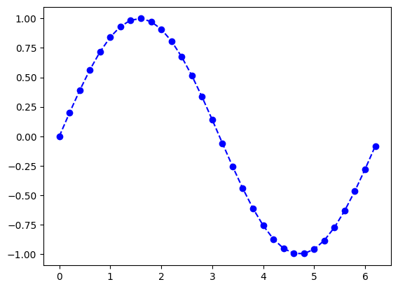

```python
plt.plot(x, y, 'bo', linestyle='dashed')
```

### ไปให้สุด ตกแต่งกราฟเต็มที่

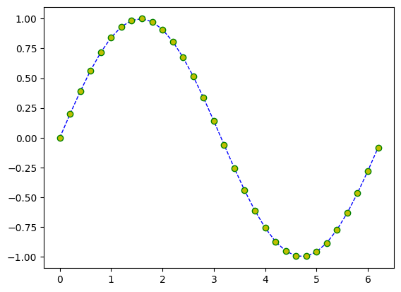

```python
plt.plot(x, y, 'bo', linewidth=1, markersize=6, linestyle='dashed', markerfacecolor='y', markeredgewidth=1,markeredgecolor='g')
```

### เมื่อเราถือสัญชาติไพธอน เราต้องไม่พิมพ์เยอะ เมื่อยนิ้ว

ชาวไพธอนจำนวนมากไม่ได้อยู่ในสาขาคอมพิวเตอร์ ความเร็วในการพิมพ์กับอุปนิสัยในการเขียนโค้ดแบบชื่อตัวแปรยาว ๆ จะไม่มีมากเท่าคนในสายคอม (ที่ถูกบริษัทบังคับให้เขียนโค้ดให้ชัด ๆ) ดังนั้นชื่ออะไรที่ยาว ๆ มักจะมีคำย่อให้ อย่าง

- markerfacecolor ก็ย่อเป็น mfc
- ส่วน markeredgewidth ย่อได้เป็น mew
- และ markeredgecolor ย่อได้เป็น mec

ปล. ที่คนสอนรู้ว่ามันย่อได้ก็เพราะอ่านเอกสารของคำสั่ง plot เอานี่แหละ ไม่ใช่ว่าอยู่ดี ๆ จะรู้เองได้

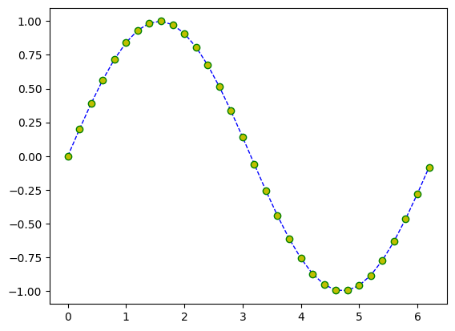

```python
plt.plot(x, y, 'bo', linewidth=1, markersize=6, linestyle='dashed', mfc='y', mew=1, mec='g')
```

## แบบฝึกหัดที่ 1

ปรับแต่งโค้ดด้านล่างให้เป็นกราฟที่ Marker เท่ห์ มีฃายเส้นที่แปลกตา พร้อมกับมีเฉดสีที่สวยสะดุดตาที่สุดที่เพื่อนแห็นแล้วต้อง**ว้าว**

- สามารถปรับแต่งจำนวนวงรอบโดยการปรับตัวคูณ `2*math.pi` และ ความห่าง(หรือความถี่)ของจุดได้ที่ตัวแปร step `np.arange(., ., step)`
- ปรับ marker อย่าง `'bo'` เป็นแบบอื่น ดูได้ใน[ลิงค์นี้](https://matplotlib.org/api/_as_gen/matplotlib.pyplot.plot.html)
- ลองปรับทีละตัวแล้วดูการเปลี่ยนแปลงของกราฟ ไม่มีผิดถูกเปลี่ยนจนกว่าจะพอใจ

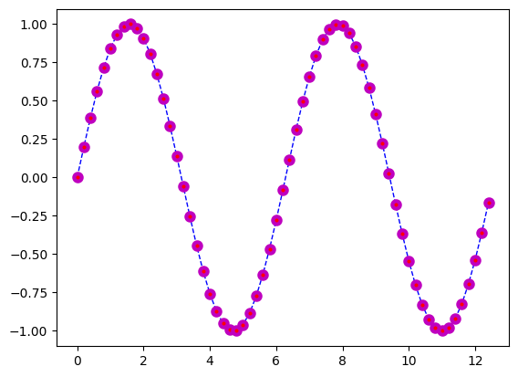

```python
x = np.arange(0.0, 4*math.pi, 0.2)
y = [math.sin(val) for val in x]
plt.plot(x, y, 'bo', linewidth=1, markersize=6, linestyle='--', mfc='r', mew=3, mec='m')
```

-จบตอน

## Part 2: Image Display

### การแสดงภาพ (Image Display)

การแสดงภาพถือเป็นส่วนสำคัญมากในการทำงานด้านการประมวลผลภาพ

- ช่วยให้เรามองเห็นสิ่งที่เกิดขึ้นจริงกับข้อมูล คล้ายกับการใช้คำสั่ง `printf` ในภาษา C หรือการใช้ตัวดีบักเพื่อดูค่าตัวแปร ใน Jupyter Notebook การแสดงภาพ
- มีประโยชน์ตรงที่เราสามารถดูผลลัพธ์ได้ทันทีโดยไม่ต้องบันทึกภาพลงไฟล์หรือดึงภาพออกจากเซิร์ฟเวอร์มาดูที่เครื่องเรา ทำให้ขั้นตอนการพัฒนาและทดลองทำได้รวดเร็วขึ้น
- ปกติแล้วถ้าจะแสดงแค่ภาพเดียวก็ทำได้ง่ายมาก แต่ในหลายกรณี เช่น การเปรียบเทียบระหว่างภาพต้นฉบับ (input) และภาพผลลัพธ์ (output) เราอาจต้องแสดงหลายภาพพร้อมกันเพื่อดูความแตกต่างได้ชัดเจน
- แต่ในตัวอย่างนี้เราจะเริ่มต้นจากการแสดงภาพเพียงภาพเดียวก่อน เพื่อให้เข้าใจพื้นฐานก่อนครับ

### **import cv2**

cv2 เป็น library ใช้ในการจัดการหลายๆอย่างในงาน computer vision (cv) ชื่อเต็มๆมันคือ opencv ซึ่งใช้กันมานานมากจนออกเวอร์ชัน2 ที่สมบูรณ์แบบมากขึ้น

```python
import cv2
import matplotlib.pyplot as plt
```

อ่านมาถึงตรงนี้ก็หยุดสักแปบนึงนะครับ เนื่องจากมีการดึงภาพมาแสดงต้องทำให้ชัวร์ว่าตอนนี้ไฟล์ jupyter นี้มี folder `images` อยู่ข้างๆนะครับ

- คำสั่ง `cv2.imread()` ใช้ในการอ่านไฟล์ภาพ
- คำสั่ง `imshow()` ใช้ในการแสดงรูปภาพ

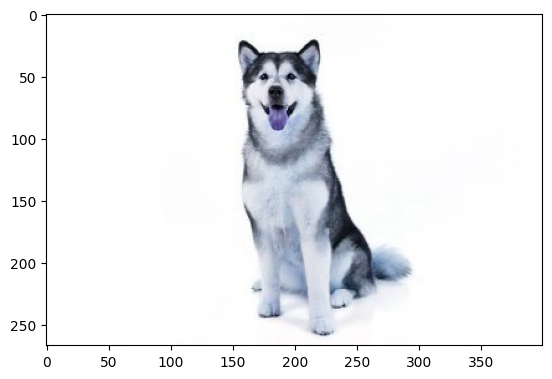

```python
file1 = 'images/AlaskanMalamute.jpg'
img1 = cv2.imread(file1)
plt.imshow(img1)
```

### แสดงภาพแบบแพ็คคู่ด้วย `subplot`

ในตัวอย่างนี้ เราจะลองแสดงภาพสองภาพพร้อมกัน โดยใช้คำสั่ง `subplot` เพื่อแบ่งพื้นที่การแสดงผลออกเป็นช่องๆ(Grid)

- เราต้องกำหนดว่าอยากแบ่งพื้นที่ออกเป็น:
  - กี่แถว (rows)
  - กี่คอลัมน์ (columns)
  - และจะวางรูปในช่องลำดับที่เท่าไหร่ (index เริ่มนับจาก 1)

ตัวอย่าง:

- `plt.subplot(1, 2, 1)`
  - หมายถึง แบ่งพื้นที่ออกเป็น 1 แถว 2 คอลัมน์ และวาดภาพในช่องที่ 1 (คือช่องซ้ายสุด)
  - ใน subplot จะใส้ได้ 1x2 ภาพ
  - ถ้าจะใส่ภาพที่ 2 จะต้องเรียก `plt.subplot(1, 2, 2)`

**ถ้าไม่ใช่ 1x2 หละอาจารย์**

- `plt.subplot(2, 3, 4)`
  - หมายถึง แบ่งพื้นที่ออกเป็น 2 แถว 3 คอลัมน์ และวาดภาพในช่องที่ 4 (ซึ่งก็คือแถวที่ 2 คอลัมน์ที่ 1, ซ้ายล่าง)

|  | col 1 | col 2 | col 3 |
| --- | --- | --- | --- |
| row 1 | ภาพ 1 | ภาพ 2 | ภาพ 3 |
| row 2 | ภาพ 4 | ภาพ 5 | ภาพ 6 |

การใช้ `subplot` มีประโยชน์มากเวลาเราต้องการเปรียบเทียบภาพหลายภาพพร้อมกัน เช่น input vs output หรือภาพก่อนและหลังผ่านการประมวลผล

```python
file1 = 'images/AlaskanMalamute.jpg'
file2 = 'images/AmericanEskimo.jpg'
img1 = cv2.imread(file1)
img2 = cv2.imread(file2)
```

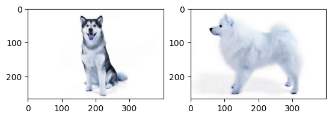

```python
plt.subplot(1, 2, 1) #(nrows, ncols, index) (index starts at 1)
plt.imshow(img1)

plt.subplot(1, 2, 2)
plt.imshow(img2)
```

### ขยายขนาดรูปภาพที่แสดงในเบราว์เซอร์

ถ้ารู้สึกว่ารูปภาพที่แสดงใน Jupyter Notebook มีขนาดเล็กเกินไป แนะนำให้กำหนดขนาดของรูปตอนพล็อตเลย จะช่วยให้มองเห็นรายละเอียดได้ชัดเจนขึ้น โดยไม่ต้องซูม

เราสามารถกำหนดขนาดของพล็อตได้ด้วยการใช้คำสั่ง `plt.figure()` แล้วใส่พารามิเตอร์ `figsize`

🔸 **วิธีการกำหนดขนาดภาพ:**

- ใช้คำสั่ง `plt.figure(figsize=(กว้าง, สูง))`
- ขนาดที่กำหนดจะอยู่ในหน่วย **นิ้ว**
- ตัวอย่างเช่น `plt.figure(figsize=(10, 5))` จะได้ภาพที่กว้าง 10 นิ้ว สูง 5 นิ้ว

🔸 **ข้อดีของการกำหนดขนาด:**

- เห็นรายละเอียดของภาพหรือกราฟชัดเจนขึ้น
- เหมาะสำหรับการพล็อตภาพความละเอียดสูง หรือเปรียบเทียบหลายภาพ
- ใช้ได้ทั้งกับกราฟเส้น, รูปภาพ, หรือ subplot ต่าง ๆ

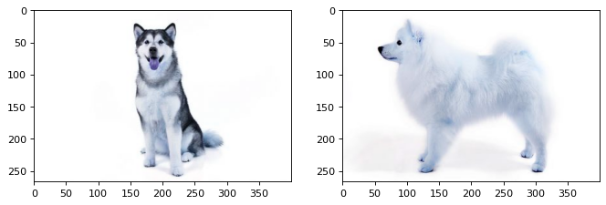

```python
plt.figure(figsize=(10, 5), dpi=80)
plt.subplot(1, 2, 1)
plt.imshow(img1)

plt.subplot(1, 2, 2)
plt.imshow(img2)
```

### แสดงภาพหลายรูปด้วย `subplot` แบบอัตโนมัติ

ถ้ามีแค่ 2–3 ภาพ เราอาจพล็อตด้วย `subplot` แบบกำหนดตำแหน่งตรง ๆ ได้ไม่ยาก  
แต่ในกรณีที่มีรูปจำนวนมาก การทำแบบนั้นจะยุ่งยากและไม่ยืดหยุ่น

ทางออกคือการใช้ **ลูป** ช่วยจัดการร่วมกับ `subplot`

- เก็บชื่อไฟล์ภาพไว้ในลิสต์ชื่อ `files`
- ใช้ลูปเพื่ออ่านภาพทั้งหมด แล้วเก็บไว้ในลิสต์ `imgs`
  - ทำให้ไม่ต้องเขียนคำสั่ง `cv2.imread()` ซ้ำหลายบรรทัด
- จากนั้นใช้ลูปวนแสดงภาพแต่ละภาพโดยใช้ `plt.subplot(...)`
  - ช่วยกำหนดตำแหน่งภาพให้อัตโนมัติในตารางของ subplot

🔸 ข้อดี:

- โค้ดสั้น กระชับ และขยายจำนวนภาพได้ง่าย
- เหมาะสำหรับการเปรียบเทียบหลายภาพ เช่น input, output, ground truth

```python
files = []
files.append('images/AlaskanMalamute.jpg')
files.append('images/AmericanEskimo.jpg')
files.append('images/AmericanFoxhound.jpg')
files.append('images/AustralianTerrier.jpg')
files.append('images/Basenji.jpg')
files.append('images/Beagle.jpg')
```

```python
imgs = []
for f in files:
    imgs.append(cv2.imread(f))
```

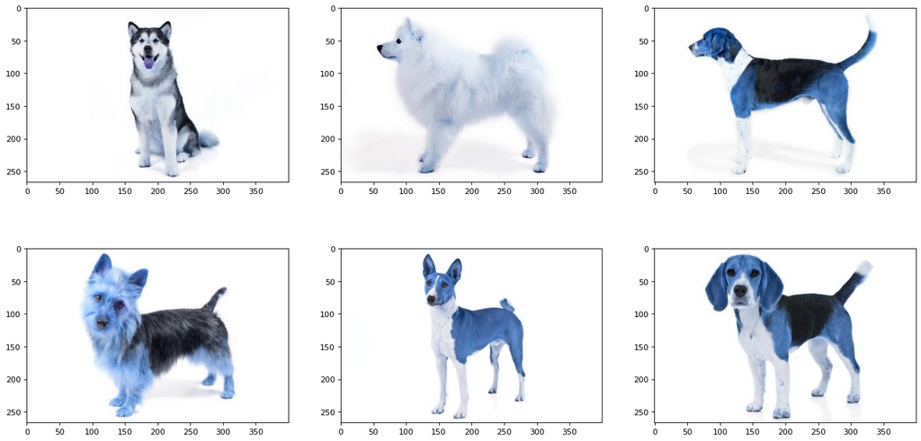

```python
plt.figure(figsize=(20, 10), dpi=80)
nrows = 2
ncols = 3
for i in range(nrows*ncols):
    plt.subplot(nrows, ncols, i+1)
    plt.imshow(imgs[i])
```

### ปรับสีให้ถูกต้อง (แก้ปัญหาสีเพี้ยน)

ถ้าสังเกตภาพที่แสดงข้างบนจะเห็นว่าสีอาจจะดูแปลก ๆ หรือไม่เป็นธรรมชาติ  
สาเหตุเกิดจากลำดับของช่องสีที่ต่างกันระหว่าง OpenCV กับไลบรารีอื่น ๆ

- OpenCV ใช้ลำดับสีแบบ **BGR** (Blue, Green, Red)
- ในขณะที่ไลบรารีอื่น เช่น Matplotlib ใช้ลำดับสีแบบ **RGB** (Red, Green, Blue)

ถ้าเราใช้ OpenCV (`cv2.imread`) ในการอ่านภาพ แล้วนำมาแสดงด้วย `matplotlib.pyplot.imshow` โดยตรง  
**สีจะเพี้ยน** เพราะช่องสีถูกตีความผิดลำดับ

**วิธีแก้**:

- ให้ใช้คำสั่ง `cv2.cvtColor()` เพื่อแปลงจาก BGR → RGB ก่อนแสดงผล

```
img_bgr = cv2.imread('images/AlaskanMalamute.jpg')
img_rgb = cv2.cvtColor(img_bgr, cv2.COLOR_BGR2RGB)
plt.imshow(img_rgb)
```

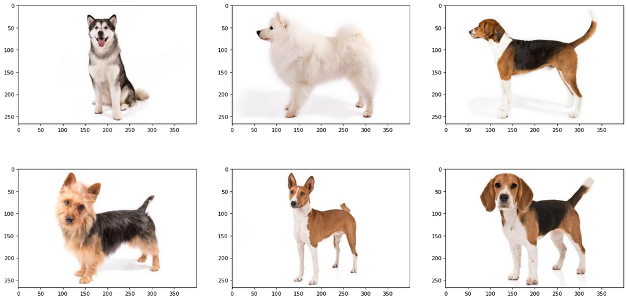

```python
plt.figure(figsize=(20, 10), dpi=80)
nrows = 2
ncols = 3
for i in range(nrows*ncols):
    plt.subplot(nrows, ncols, i+1)
    plt.imshow(cv2.cvtColor(imgs[i], cv2.COLOR_BGR2RGB))
```

### การปรับสีเพิ่มเติม

นอกเหนือจาก RGB หรือ BGR แล้ว ยังมี colourmap แบบอื่นอีกด้วย เช่น Greyscale หรือ ขาวเทา สามารถปรับได้โดยการใช้ `cv2.COLOR_BGR2GRAY`

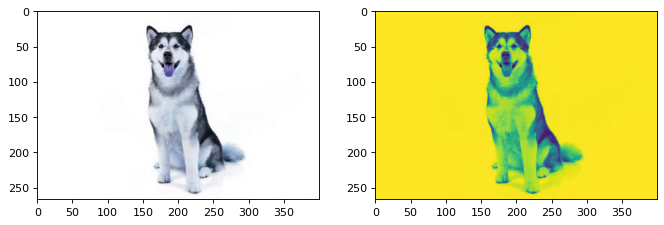

```python
plt.figure(figsize=(10, 5), dpi=80)
plt.subplot(1, 2, 1)
plt.imshow(imgs[0])

plt.subplot(1, 2, 2)
plt.imshow(cv2.cvtColor(imgs[0],cv2.COLOR_BGR2GRAY))
```

อ่าวอาจารย์ทำไมถึงเป็นมันไม่เห็นจะเป็นสีขาวดำเลยครับ เหลืองไปหมดเลย!!! เกิดอะไรขึ้น???

- `cv2.cvtColor(..., cv2.COLOR_BGR2GRAY)` จะให้ภาพแบบขาวดำจริง (2 มิติ)
- แต่ `matplotlib.pyplot.imshow()` ถ้าไม่ได้ระบุ `cmap` จะใช้ colormap เริ่มต้น (เช่น `viridis`) ซึ่งเป็นโทนสีหลากหลาย
- ดังนั้น `imshow()` จะตีความ 2D array ว่าเป็นข้อมูลที่ต้องการแสดงสีตามแผนที่สี (`viridis`) แทนที่จะตีความว่าเป็น grayscale

**วิธีแก้ไข**:

ให้ระบุ `cmap='gray'` เพื่อบอก Matplotlib ว่าเราต้องการแสดงภาพแบบ grayscale จริง ๆ

```
plt.imshow(cv2.cvtColor(imgs[0],cv2.COLOR_BGR2GRAY), cmap="gray")
```

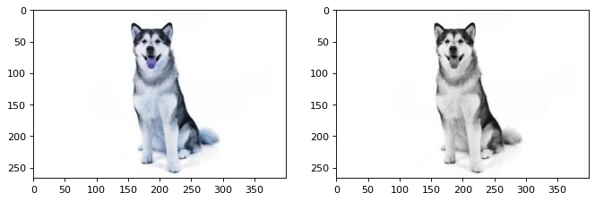

```python
plt.figure(figsize=(10, 5), dpi=80)
plt.subplot(1, 2, 1)
plt.imshow(imgs[0])

plt.subplot(1, 2, 2)
plt.imshow(cv2.cvtColor(imgs[0],cv2.COLOR_BGR2GRAY), cmap='gray')
```

## แบบฝึกหัดที่ 2

เราจะมาลองจำลองการเปรี่ยบเทียบภาพที่ผ่านการปรุงแต่งหลายๆให้อยู่ในการพล็อตเดียวกัน

- ภาพที่1 เป็นภาพปกติ
- ภาพที่2 เป็นขาวเทา cmap ขาวเทา
- ภาพที่3 เป็นสีRGB
- ภาพที่4 เป็นสีขาวเทา cmap อะไรก็ได้ที่ชอบ ดูได้โดยการเรียก `print(plt.colormaps())` อยากหมาไซสีอะไรปรับเลย

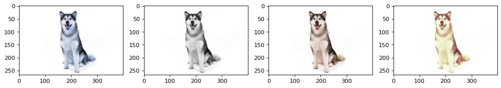

```python
plt.figure(figsize=(15, 5), dpi=80)
# 1st
plt.subplot(1, 4, 1)
plt.imshow(imgs[0])
# 2nd
plt.subplot(1, 4, 2)
plt.imshow(cv2.cvtColor(imgs[0],cv2.COLOR_BGR2GRAY), cmap='gray')
# 3rd
plt.subplot(1, 4, 3)
plt.imshow(cv2.cvtColor(imgs[0], cv2.COLOR_BGR2RGB))
# 4th
plt.subplot(1,4,4)
plt.imshow(cv2.cvtColor(imgs[0], cv2.COLOR_BGR2GRAY), cmap = 'pink')
```

## แบบฝึกหัดที่ 3

ทำการลูป plot แบบ subplot grid 6x4 ที่ภายในมีภาพจำนวน 24 ภาพ

- แต่ละแถวจะเป็นภาพของ imgs ที่ index i+1 เช่น แถวแรกก็เป็นภาพ `imgs[0+1]`
- ในทุกๆแถวจะมีการแสดงภาพ 4 ภาพ(คอลลัมน์) ที่เป็นการพล็อตสีเหมือนกับแบบฝึกหัดที่ 2

ทำเสร็จเก็บกระเป๋าไปทานข้าวได้เลยครับ อย่าลืมส่งแล็ปนี้เข้า Assignment ด้วยนะครับ

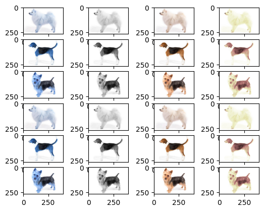

```python
nrows = 6
ncols = 4
count = 0
position = 0

for i in range(nrows):
    check = 0
    for j in range(ncols):
        plt.subplot(nrows , ncols , position+1)
        plt.imshow(imgs[count+1])
        if check == 1:
            plt.imshow(cv2.cvtColor(imgs[count + 1],cv2.COLOR_BGR2GRAY), cmap='gray')
        if check == 2:
            plt.imshow(cv2.cvtColor(imgs[count + 1], cv2.COLOR_BGR2RGB))
        if check == 3:
            plt.imshow(cv2.cvtColor(imgs[count + 1], cv2.COLOR_BGR2GRAY), cmap = 'pink')
        position = position + 1
        check = check + 1
    count = count + 1
    if count == 3 :
        count = 0
```

Credit: Dog Photos: https://www.akc.org/dog-breeds/